# Dave Andison’s fire data Severity models

Collinearity among candidate predictors

Ceres Barros

Posit Assistant (AI assistant; drafted the collinearity checks and variable selection, Oct 2026)

02/04/2019

## Approach

Collinearity is checked within three groups of candidate predictors: topography, fire weather, and vegetation. For each group we report:

- pairwise Spearman correlations (rank-based, robust to the skewed and bounded distributions of many predictors);
- variance inflation factors (VIF), which capture multicollinearity among more than two variables at once. VIF > 5 is flagged, VIF > 10 is severe.

Pixel-level checks use one random sample of pixels, which keeps the computations fast with little loss of precision. Fire weather is constant within each fire, so it is checked at the fire level instead (one row per fire); pixel-level correlations would weight fires by their size.

## Topographic variables

`Aspect` uses the code `-117` for flat pixels (12% of pixels), so it is set to `NA` here. Its circular scale makes linear correlations meaningless anyway; `SCOS`/`SSIN` (slope × cos/sin of aspect) are the linear alternatives.

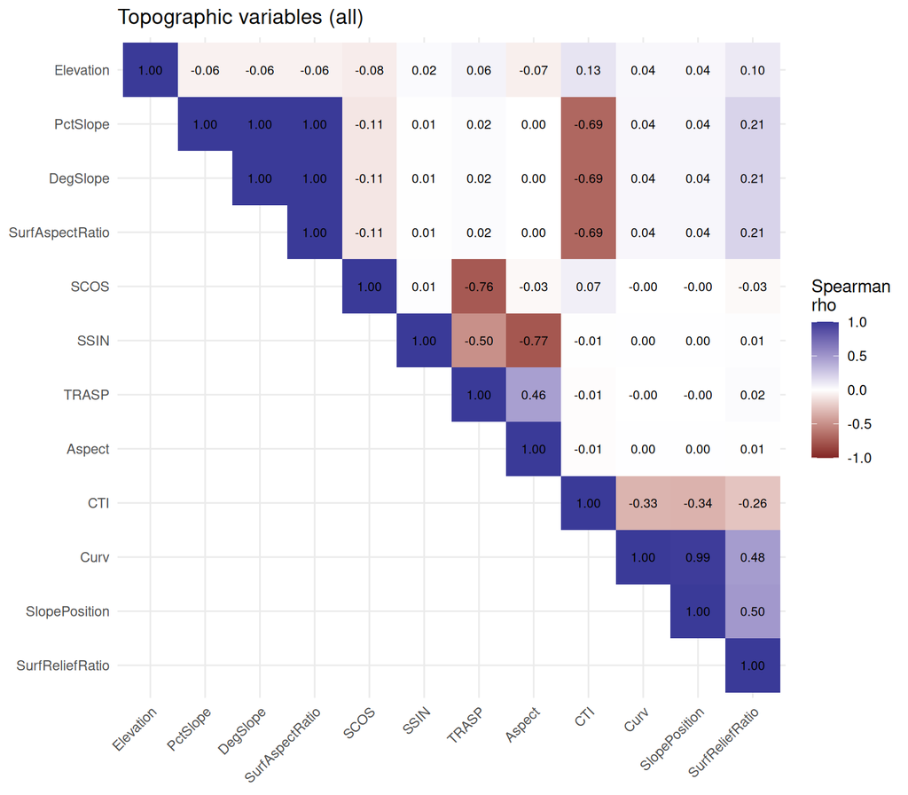

```
##               var1     var2    rho
##             <char>   <char>  <num>
## 1:        DegSlope PctSlope  1.000
## 2: SurfAspectRatio PctSlope  1.000
## 3: SurfAspectRatio DegSlope  1.000
## 4:   SlopePosition     Curv  0.986
## 5:          Aspect     SSIN -0.768
## 6:           TRASP     SCOS -0.758
```

`SurfAspectRatio` is an exact function of slope (constant multiple of sec(slope)); `DegSlope` is a monotonic transform of `PctSlope`:

```
##    SurfAspectRatio_over_secSlope
##                            <num>
## 1:                      537.8481
## 2:                      537.8488
```

VIFs for the full set and for the candidate set (dropping redundant or circular variables):

```
##   SlopePosition            Curv            SCOS        PctSlope             CTI
##          165.87          165.77            1.96            1.91            1.72
##           TRASP SurfReliefRatio       Elevation            SSIN
##            1.67            1.27            1.26            1.25
```

```
##        PctSlope             CTI            SCOS SurfReliefRatio       Elevation
##            1.79            1.65            1.34            1.26            1.25
##            SSIN
##            1.04
```

## Fire-weather variables

Weather summaries (first three days of each fire) take a single value per fire, so correlations are computed across fires.

```
## [1] 36
```

```
##    startJulDay meanTemp minTemp maxTemp cvTemp rangeRH meanRH minRH maxRH  cvRH
##          <int>    <int>   <int>   <int>  <int>   <int>  <int> <int> <int> <int>
## 1:          22       35      35      35     35      35     35    35    35    35
##    meanWS minWS maxWS  cvWS rangeWS meanRain minRain maxRain cvRain rangeRain
##     <int> <int> <int> <int>   <int>    <int>   <int>   <int>  <int>     <int>
## 1:     35    35    35    35      35       34       3      34     24        34
##    meanFFMC minFFMC maxFFMC cvFFMC rangeFFMC meanDMC minDMC maxDMC cvDMC
##       <int>   <int>   <int>  <int>     <int>   <int>  <int>  <int> <int>
## 1:       35      35      35     35        35      35     35     35    35
##    rangeDMC meanDC minDC maxDC  cvDC rangeDC meanISI minISI maxISI cvISI
##       <int>  <int> <int> <int> <int>   <int>   <int>  <int>  <int> <int>
## 1:       35     35    35    35    35      35      35     34     35    35
##    rangeISI meanBUI minBUI maxBUI cvBUI rangeBUI meanFWI minFWI maxFWI cvFWI
##       <int>   <int>  <int>  <int> <int>    <int>   <int>  <int>  <int> <int>
## 1:       35      35     35     35    35       35      35     34     35    35
##    rangeFWI
##       <int>
## 1:       35
```

With 36 fires and 50 weather variables, VIFs for the full set cannot be computed (more variables than fires); correlations are the main diagnostic here.

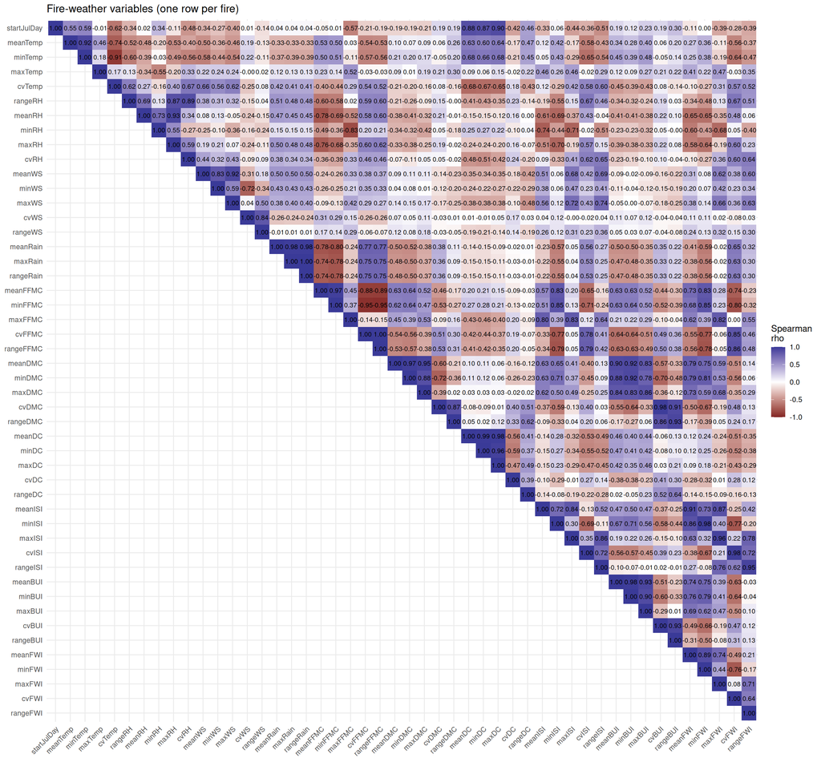

```
##          var1        var2    rho
##        <char>      <char>  <num>
##  1: rangeRain     maxRain  1.000
##  2: rangeFFMC      cvFFMC  0.995
##  3:     minDC      meanDC  0.993
##  4:     cvBUI       cvDMC  0.985
##  5:    minBUI     meanBUI  0.985
##  6:   maxRain    meanRain  0.984
##  7: rangeRain    meanRain  0.984
##  8:     maxDC      meanDC  0.983
##  9:    minFWI      minISI  0.979
## 10:     cvFWI       cvISI  0.977
## 11:    minDMC     meanDMC  0.971
## 12:   minFFMC    meanFFMC  0.966
## 13:     maxDC       minDC  0.960
```

[output cut: 55 more lines]

Within each weather variable, `mean`, `min`, `max` and `range` are expected to be strongly related; across variables, the FWI-system indices are built from one another (e.g. BUI from DMC and DC; FWI from ISI and BUI).

```
##  meanFWI  meanBUI  meanDMC  meanISI   meanDC meanFFMC   meanWS meanRain
##   139.29   113.27    74.54    62.05    14.40     8.40     5.83     5.75
##   meanRH meanTemp
##     5.33     3.44
```

## Vegetation variables

The species-group percentages (`FlamConif`, `Abie`, `Lari`, `Decid`) are a composition: they sum to 100 on forested pixels and to 0 on non-forested pixels (where forest attributes are filled with 0):

```
##    isForest      n   pctSum100     pctSum0
##      <lgcl>  <int>       <num>       <num>
## 1:     TRUE 187497 0.995093255 0.004906745
## 2:    FALSE  12503 0.004398944 0.995601056
```

This closure makes the four groups, plus `isForest`, linearly dependent: any one can be computed from the others. Including all of them inflates VIFs regardless of the ecological relationships between them.

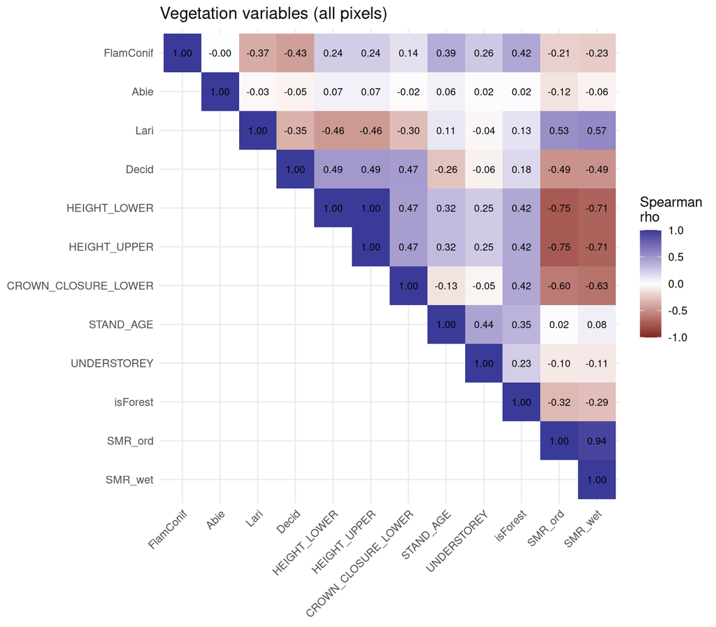

```
##            var1         var2    rho
##          <char>       <char>  <num>
## 1: HEIGHT_UPPER HEIGHT_LOWER  1.000
## 2:      SMR_wet      SMR_ord  0.944
## 3:      SMR_ord HEIGHT_LOWER -0.754
## 4:      SMR_ord HEIGHT_UPPER -0.754
## 5:      SMR_wet HEIGHT_LOWER -0.714
## 6:      SMR_wet HEIGHT_UPPER -0.714
```

Forest attributes are 0 on non-forested pixels, so correlations over all pixels partly reflect the forest/non-forest split. Restricting to forested pixels shows the relationships within forests:

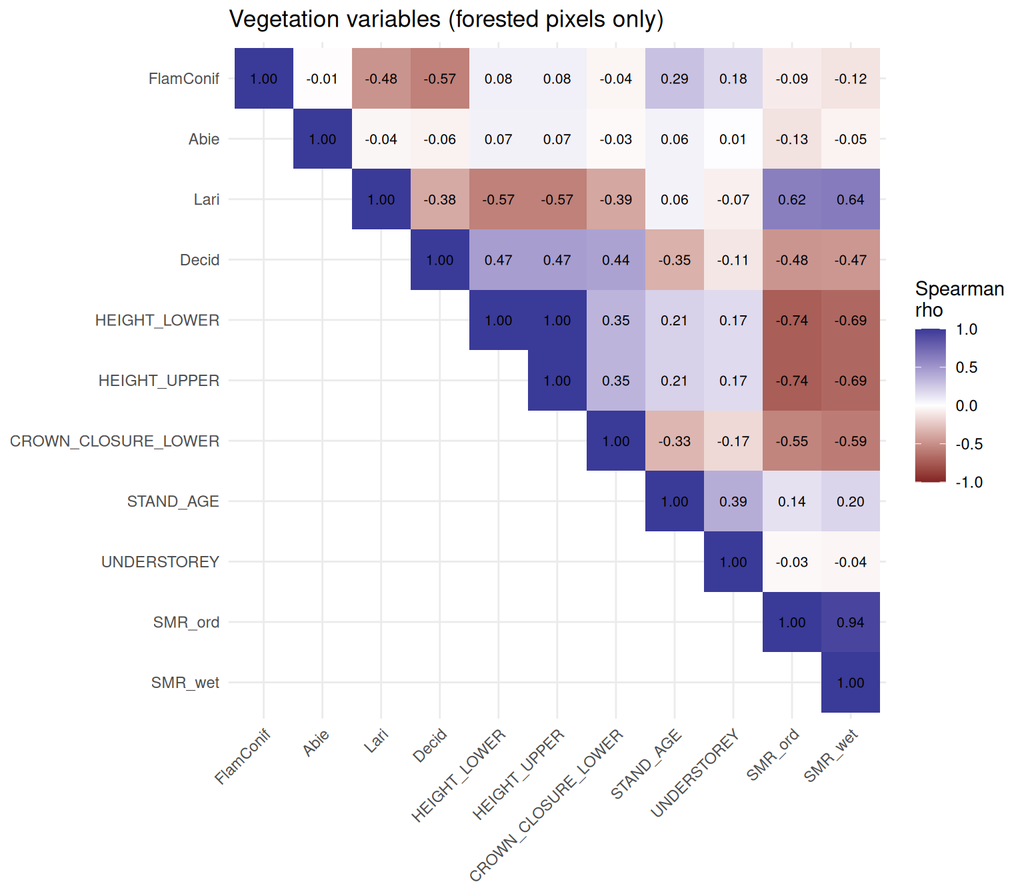

```
##            var1         var2    rho
##          <char>       <char>  <num>
## 1: HEIGHT_UPPER HEIGHT_LOWER  1.000
## 2:      SMR_wet      SMR_ord  0.938
## 3:      SMR_ord HEIGHT_LOWER -0.736
## 4:      SMR_ord HEIGHT_UPPER -0.736
```

VIFs for the candidate set used in model selection, and with one composition group dropped (here `FlamConif`, the reference group, which is present on almost all forested pixels):

```
##    FlamConif        Decid     isForest         Lari HEIGHT_LOWER      SMR_wet
##        36.95        18.86        17.40        16.26         3.16         2.05
##  UNDERSTOREY         Abie
##         1.15         1.07
```

```
## HEIGHT_LOWER      SMR_wet     isForest         Lari        Decid  UNDERSTOREY
##         3.05         2.05         1.71         1.54         1.28         1.15
##         Abie
##         1.00
```

## Non-collinear variable lists

Selection rule, applied within each group:

1. Remove structural redundancies by hand (exact transforms, duplicates, circular variables, compositional closure), as shown above.
2. Among the remaining pool, drop variables with pairwise |Spearman ρ| ≥ 0.7, using `caret::findCorrelation()` (exact = TRUE), which, for each correlated pair, removes the variable with the larger mean absolute correlation with all others.
3. Iteratively drop the variable with the highest VIF until all VIFs are < 5.

Pools are the candidate predictors used for model selection in `DAfires_sevModelsGAMLSS_ngbAvg.Rmd`. Categorical candidates (`LandCover`, `DIST1`) are not covered by these numeric checks; they are listed separately. Note that `isForest` is a collapse of `LandCover` (`PF` vs the rest), so the two should not enter the same model.

```
## Dropping cvDMC (VIF = 5.01)
```

```
## $topographic
## [1] "Elevation"       "PctSlope"        "SCOS"            "SSIN"
## [5] "CTI"             "SurfReliefRatio"
##
## $vegetation
## [1] "Abie"         "Lari"         "Decid"        "HEIGHT_LOWER" "UNDERSTOREY"
## [6] "isForest"
##
## $climate
## [1] "cvFFMC" "maxDMC" "maxDC"  "cvDC"   "maxISI"
```

VIFs of the retained sets:

```
##        PctSlope             CTI            SCOS SurfReliefRatio       Elevation
##            1.79            1.65            1.34            1.26            1.25
##            SSIN
##            1.04
```

```
## HEIGHT_LOWER     isForest         Lari        Decid  UNDERSTOREY         Abie
##         2.37         1.70         1.40         1.28         1.13         1.00
```

```
## maxISI maxDMC cvFFMC  maxDC   cvDC
##   2.01   1.94   1.38   1.29   1.10
```

The lists are saved to `analyses/outputs/nonCollinearVars.rds`.